# Bar Plots of Species per Barcode

Quinones-Sanchez, Carlos L.

2024-07-09

```r
knitr::opts_chunk$set(echo = TRUE)
```

# Analysis of Species Detected per Barcode/Sample

## Importing the libraries

This are some packages that will be used to make the bar plots.

To run the code, press Ctrl + Shift + Enter.

```r
library(tidyverse)
```

```r
library(ggplot2)
library(RColorBrewer)
library(randomcoloR)
```

## Importing the data

*This part was made using the documents path in my computer. Changes will likely be necessary when running the script to ensure the data can be imported.*

To ensure you can import the data, find the file using the lower right window inside RStudio (->). Once you find the file, click on it and press Import Dataset. This will bring up a window with a preview of the data, import options, and a code preview. In the code preview area, copy the read_csv(“name_of_file_here.csv”) part and paste it in the chunk below (substituing the read_csv() function already present).

*It is recommended that you keep the same variable name (barcode_data) when importing the data, as the rest of the script was made using that variable. If you wish to change the variable name, make sure to change everything that says “barcode_data” and substitue it for the variable you set, otherwise an “object not found” error will be triggered.*

```r
# This is a chunk

library(readr)
# getwd()
barcode_data <- read.csv("CSV_Files/data_jan/classification_16s_barcode_v1.csv") #Substitue this read_csv() with the one copied from the code preview

head(barcode_data)
```

```
##                                 readid                                    runid
## 1 00222076-3fba-455a-a46c-27cc9adeb244 310c5cba911aacc4c4378033ca05faa024174a31
## 2 00a1be46-f4ed-4fba-804b-15fef0f9c395 310c5cba911aacc4c4378033ca05faa024174a31
## 3 00bb1b00-a1c8-4d87-90f0-fb5744f8289c 310c5cba911aacc4c4378033ca05faa024174a31
## 4 01349ee7-0e7e-41a9-9763-722981df27e1 310c5cba911aacc4c4378033ca05faa024174a31
## 5 0182e11a-b407-43c4-8b69-4c2ced3f0815 310c5cba911aacc4c4378033ca05faa024174a31
## 6 01b4f629-aa66-44be-8e59-be60905a600f 310c5cba911aacc4c4378033ca05faa024174a31
##     barcode               exit_status   taxid species_taxid
## 1 barcode02 Classification successful     433       1088868
## 2 barcode02 Classification successful     433       1088868
## 3 barcode02 Classification successful 1196095       1196095
## 4 barcode02 Classification successful 1240483       1267021
## 5 barcode02 Classification successful     433       1088868
## 6 barcode02 Classification successful     433       1236525
##                           species accuracy genus_taxid       genus lca
## 1 Commensalibacter intestini A911    93.03          -1        <NA>   1
## 2 Commensalibacter intestini A911    91.56          -1        <NA>   1
## 3             Gilliamella apicola    88.26     1193503 Gilliamella   0
## 4              Frischella perrara    86.31          -1        <NA>   1
## 5 Commensalibacter intestini A911    96.10          -1        <NA>   1
## 6       Asaia platycodi JCM 25414    87.64          -1        <NA>   1
```

## Making the bar plots for each barcode

This part of the script is where the bar plots can be made using the ggplot2 library. To organize this section, I recommend putting a subtitle indicating which barcode is being plotted (Similar to what is done for barcode 1).

*The plot for barcode01 is already made. To make the bar plots for the other samples, copy and paste the entire chunk and change the barcode number inside the quotation marks in the filter(barcode == “barcode01”…) line. Ggplot offers many ways to personalize the plots and make them presentable for publication, like changing the colour palette, formatting some text, or even adding labels to certain parts of the graph. If you have any questions or want to change details of the plot, feel free to contact Carlos for help.*

**VERY IMPORTANT**: The ggsave() function allows you to save the **LAST MADE PLOT** using the format of your choice. **IT IS IMPERATIVE THAT YOU CHANGE THE NAME OF THE FILE INSIDE GGSAVE() OR EVERY PLOT YOU SAVE WILL SUBSTITUE THE LAST ONE YOU MADE**. Be very mindful of changing the barcode number inside ggsave() before running the full code, as to ensure you don’t accidentally delete a different figure. To save the figure, remove the hashtag (#) before ggsave().

*Note:* To change the format that the figure will be saved in, change the .png in the name of the figure in ggsave() to the format of your choice (eg.: .jpeg, .pdf, .tiff, etc.). The figure will appeared saved inside the same folder the .rproject file is saved (ideally, it’s the same folder this rmarkdown was saved in, but that might not always be the case). Ggsave() also offers options to change the sized of the figure that gets saved, in case it is too small to see it or use it for publication/poster. If you have any questions or need help changing the save settings or finding the figure, feel free to contact Carlos for help.

### Barcode 1

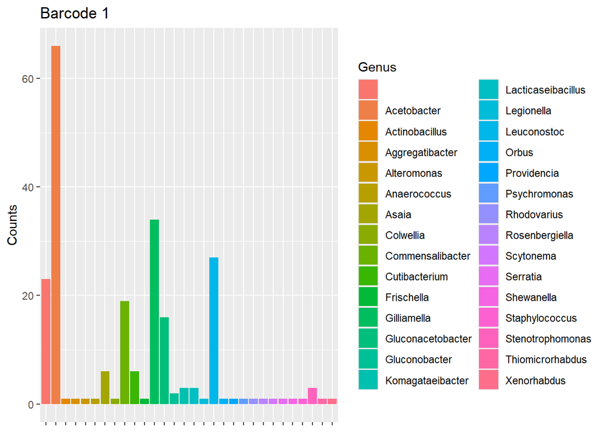

```r
#This is the code to make the plots

barcode_data %>%
  select(barcode, genus) %>%
  filter(barcode == "barcode01" & !is.na(genus)) %>% #Change the "barcode01" argument for the barcode you wish to plot
  ggplot() +
  geom_bar(aes(x = genus, fill = genus)) +
  labs(title = "Barcode 1", y = "Counts", fill = "Genus") +
  theme(axis.text.x = element_blank(), axis.title.x = element_blank())
```

```r
#ggsave("Bar_plot_genus_barcode01.png") #REMEMBER TO CHANGE THE NAME TO THE BARCODE YOU ARE PLOTTING
```

#### Counting the genus to compare with Epi2Me results

```r
barcode_data %>%
  select(barcode, genus) %>%
  filter(barcode == "barcode01" & !is.na(genus)) %>%
  count(genus)
```

```
##                 genus  n
## 1                     23
## 2         Acetobacter 66
## 3      Actinobacillus  1
## 4     Aggregatibacter  1
## 5         Alteromonas  1
## 6        Anaerococcus  1
## 7               Asaia  6
## 8           Colwellia  1
## 9    Commensalibacter 19
## 10      Cutibacterium  6
## 11         Frischella  1
## 12        Gilliamella 34
## 13  Gluconacetobacter 16
## 14      Gluconobacter  2
```

[output cut: 16 more lines]

### Barcode 2

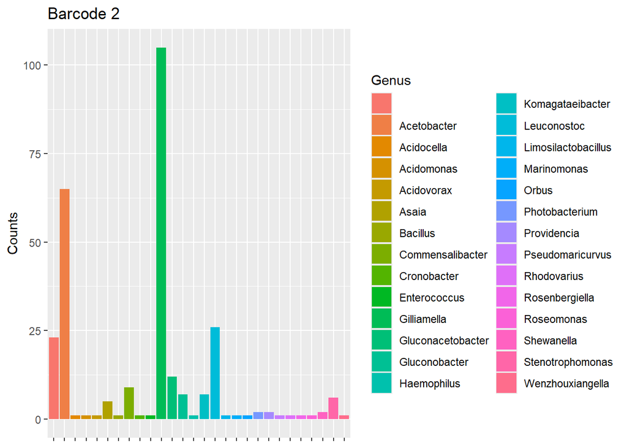

```r
#This is the code to make the plots

barcode_data %>%
  select(barcode, genus) %>%
  filter(barcode == "barcode02" & !is.na(genus)) %>% #Change the "barcode01" argument for the barcode you wish to plot
  ggplot() +
  geom_bar(aes(x = genus, fill = genus)) +
  labs(title = "Barcode 2", y = "Counts", fill = "Genus") +
  theme(axis.text.x = element_blank(), axis.title.x = element_blank())
```

```r
#ggsave("Bar_plot_genus_barcode02.png") #REMEMBER TO CHANGE THE NAME TO THE BARCODE YOU ARE PLOTTING
```

#### Counting the genus to compare with Epi2Me results

```r
barcode_data %>%
  select(barcode, genus) %>%
  filter(barcode == "barcode02" & !is.na(genus)) %>%
  count(genus)
```

```
##                  genus   n
## 1                       23
## 2          Acetobacter  65
## 3           Acidocella   1
## 4           Acidomonas   1
## 5           Acidovorax   1
## 6                Asaia   5
## 7             Bacillus   1
## 8     Commensalibacter   9
## 9          Cronobacter   1
## 10        Enterococcus   1
## 11         Gilliamella 105
## 12   Gluconacetobacter  12
## 13       Gluconobacter   7
## 14         Haemophilus   1
## 15    Komagataeibacter   7
## 16         Leuconostoc  26
## 17 Limosilactobacillus   1
## 18         Marinomonas   1
## 19               Orbus   1
## 20      Photobacterium   2
## 21         Providencia   2
## 22    Pseudomaricurvus   1
## 23         Rhodovarius   1
## 24      Rosenbergiella   1
## 25          Roseomonas   1
## 26          Shewanella   2
## 27    Stenotrophomonas   6
## 28    Wenzhouxiangella   1
```

### Barcode 3

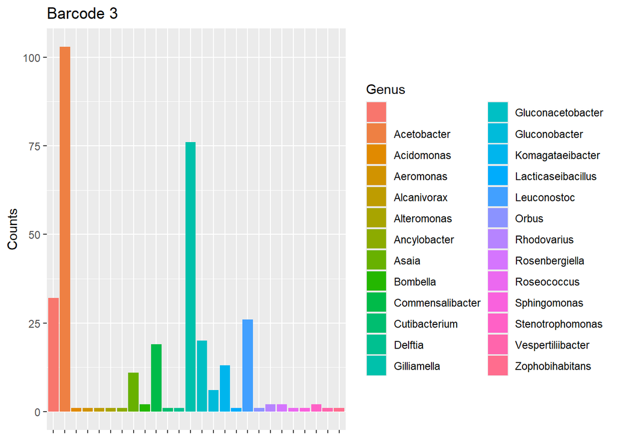

```r
#This is the code to make the plots

barcode_data %>%
  select(barcode, genus) %>%
  filter(barcode == "barcode03" & !is.na(genus)) %>% #Change the "barcode01" argument for the barcode you wish to plot
  ggplot() +
  geom_bar(aes(x = genus, fill = genus)) +
  labs(title = "Barcode 3", y = "Counts", fill = "Genus") +
  theme(axis.text.x = element_blank(), axis.title.x = element_blank())
```

```r
#ggsave("Bar_plot_genus_barcode03.png") #REMEMBER TO CHANGE THE NAME TO THE BARCODE YOU ARE PLOTTING
```

#### Counting the genus to compare with Epi2Me results

```r
barcode_data %>%
  select(barcode, genus) %>%
  filter(barcode == "barcode03" & !is.na(genus)) %>%
  count(genus)
```

```
##                 genus   n
## 1                      32
## 2         Acetobacter 103
## 3          Acidomonas   1
## 4           Aeromonas   1
## 5         Alcanivorax   1
## 6         Alteromonas   1
## 7        Ancylobacter   1
## 8               Asaia  11
## 9            Bombella   2
## 10   Commensalibacter  19
## 11      Cutibacterium   1
## 12            Delftia   1
## 13        Gilliamella  76
## 14  Gluconacetobacter  20
## 15      Gluconobacter   6
## 16   Komagataeibacter  13
## 17 Lacticaseibacillus   1
## 18        Leuconostoc  26
## 19              Orbus   1
## 20        Rhodovarius   2
## 21     Rosenbergiella   2
## 22        Roseococcus   1
## 23       Sphingomonas   1
## 24   Stenotrophomonas   2
## 25  Vespertiliibacter   1
## 26    Zophobihabitans   1
```

### Barcode 4

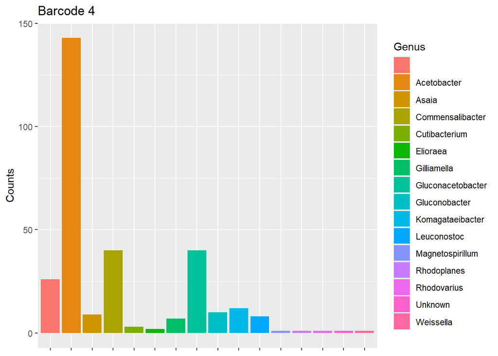

```r
#This is the code to make the plots

barcode_data %>%
  select(barcode, genus) %>%
  filter(barcode == "barcode04" & !is.na(genus)) %>% #Change the "barcode01" argument for the barcode you wish to plot
  ggplot() +
  geom_bar(aes(x = genus, fill = genus)) +
  labs(title = "Barcode 4", y = "Counts", fill = "Genus") +
  theme(axis.text.x = element_blank(), axis.title.x = element_blank())
```

```r
#ggsave("Bar_plot_genus_barcode04.png") #REMEMBER TO CHANGE THE NAME TO THE BARCODE YOU ARE PLOTTING
```

#### Counting the genus to compare with Epi2Me results

```r
barcode_data %>%
  select(barcode, genus) %>%
  filter(barcode == "barcode04" & !is.na(genus)) %>%
  count(genus)
```

```
##                genus   n
## 1                     26
## 2        Acetobacter 143
## 3              Asaia   9
## 4   Commensalibacter  40
## 5      Cutibacterium   3
## 6           Elioraea   2
## 7        Gilliamella   7
## 8  Gluconacetobacter  40
## 9      Gluconobacter  10
## 10  Komagataeibacter  12
## 11       Leuconostoc   8
## 12  Magnetospirillum   1
## 13       Rhodoplanes   1
## 14       Rhodovarius   1
## 15           Unknown   1
## 16         Weissella   1
```

### Barcode 5

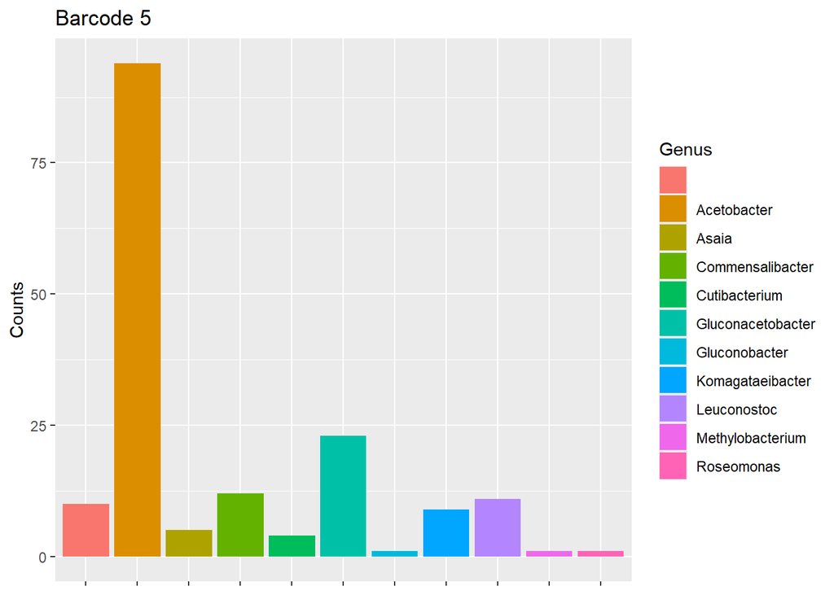

```r
#This is the code to make the plots

barcode_data %>%
  select(barcode, genus) %>%
  filter(barcode == "barcode05" & !is.na(genus)) %>% #Change the "barcode01" argument for the barcode you wish to plot
  ggplot() +
  geom_bar(aes(x = genus, fill = genus)) +
  labs(title = "Barcode 5", y = "Counts", fill = "Genus") +
  theme(axis.text.x = element_blank(), axis.title.x = element_blank())
```

```r
#ggsave("Bar_plot_genus_barcode05.png") #REMEMBER TO CHANGE THE NAME TO THE BARCODE YOU ARE PLOTTING
```

#### Counting the genus to compare with Epi2Me results

```r
barcode_data %>%
  select(barcode, genus) %>%
  filter(barcode == "barcode05" & !is.na(genus)) %>%
  count(genus)
```

```
##                genus  n
## 1                    10
## 2        Acetobacter 94
## 3              Asaia  5
## 4   Commensalibacter 12
## 5      Cutibacterium  4
## 6  Gluconacetobacter 23
## 7      Gluconobacter  1
## 8   Komagataeibacter  9
## 9        Leuconostoc 11
## 10  Methylobacterium  1
## 11        Roseomonas  1
```

### Barcode 6

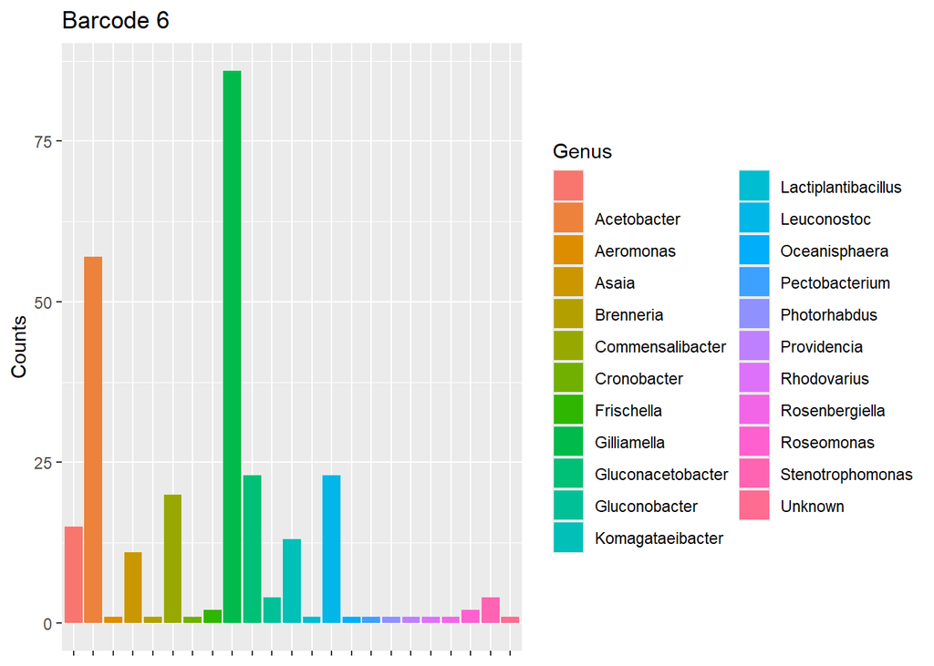

```r
#This is the code to make the plots

barcode_data %>%
  select(barcode, genus) %>%
  filter(barcode == "barcode06" & !is.na(genus)) %>% #Change the "barcode01" argument for the barcode you wish to plot
  ggplot() +
  geom_bar(aes(x = genus, fill = genus)) +
  labs(title = "Barcode 6", y = "Counts", fill = "Genus") +
  theme(axis.text.x = element_blank(), axis.title.x = element_blank())
```

```r
#ggsave("Bar_plot_genus_barcode06.png") #REMEMBER TO CHANGE THE NAME TO THE BARCODE YOU ARE PLOTTING
```

#### Counting the genus to compare with Epi2Me results

```r
barcode_data %>%
  select(barcode, genus) %>%
  filter(barcode == "barcode06" & !is.na(genus)) %>%
  count(genus)
```

```
##                  genus  n
## 1                      15
## 2          Acetobacter 57
## 3            Aeromonas  1
## 4                Asaia 11
## 5            Brenneria  1
## 6     Commensalibacter 20
## 7          Cronobacter  1
## 8           Frischella  2
## 9          Gilliamella 86
## 10   Gluconacetobacter 23
## 11       Gluconobacter  4
## 12    Komagataeibacter 13
## 13 Lactiplantibacillus  1
## 14         Leuconostoc 23
## 15       Oceanisphaera  1
## 16      Pectobacterium  1
## 17        Photorhabdus  1
## 18         Providencia  1
## 19         Rhodovarius  1
## 20      Rosenbergiella  1
## 21          Roseomonas  2
## 22    Stenotrophomonas  4
## 23             Unknown  1
```

### Barcode 8

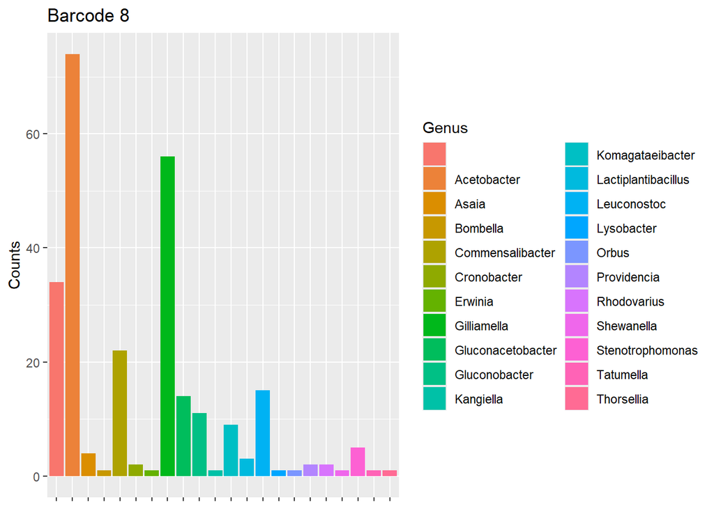

```r
#This is the code to make the plots

barcode_data %>%
  select(barcode, genus) %>%
  filter(barcode == "barcode08" & !is.na(genus)) %>% #Change the "barcode01" argument for the barcode you wish to plot
  ggplot() +
  geom_bar(aes(x = genus, fill = genus)) +
  labs(title = "Barcode 8", y = "Counts", fill = "Genus") +
  theme(axis.text.x = element_blank(), axis.title.x = element_blank())
```

```r
#ggsave("Bar_plot_genus_barcode08.png") #REMEMBER TO CHANGE THE NAME TO THE BARCODE YOU ARE PLOTTING
```

#### Counting the genus to compare with Epi2Me results

```r
barcode_data %>%
  select(barcode, genus) %>%
  filter(barcode == "barcode08" & !is.na(genus)) %>%
  count(genus)
```

```
##                  genus  n
## 1                      34
## 2          Acetobacter 74
## 3                Asaia  4
## 4             Bombella  1
## 5     Commensalibacter 22
## 6          Cronobacter  2
## 7              Erwinia  1
## 8          Gilliamella 56
## 9    Gluconacetobacter 14
## 10       Gluconobacter 11
## 11           Kangiella  1
## 12    Komagataeibacter  9
## 13 Lactiplantibacillus  3
## 14         Leuconostoc 15
## 15          Lysobacter  1
## 16               Orbus  1
## 17         Providencia  2
## 18         Rhodovarius  2
## 19          Shewanella  1
## 20    Stenotrophomonas  5
## 21           Tatumella  1
## 22          Thorsellia  1
```

### Barcode 9

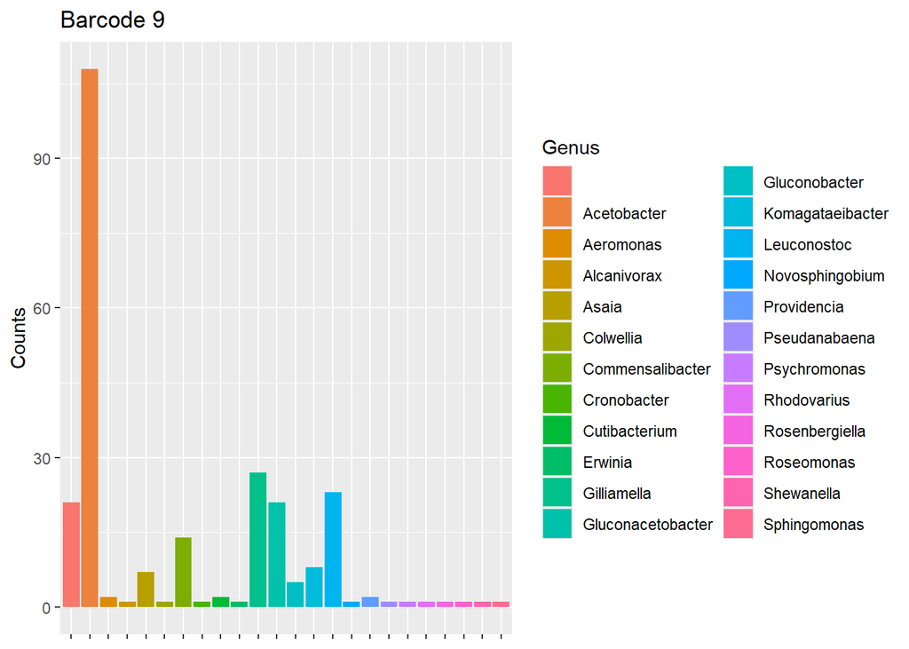

```r
#This is the code to make the plots

barcode_data %>%
  select(barcode, genus) %>%
  filter(barcode == "barcode09" & !is.na(genus)) %>% #Change the "barcode01" argument for the barcode you wish to plot
  ggplot() +
  geom_bar(aes(x = genus, fill = genus)) +
  labs(title = "Barcode 9", y = "Counts", fill = "Genus") +
  theme(axis.text.x = element_blank(), axis.title.x = element_blank())
```

```r
#ggsave("Bar_plot_genus_barcode09.png") #REMEMBER TO CHANGE THE NAME TO THE BARCODE YOU ARE PLOTTING
```

#### Counting the genus to compare with Epi2Me results

```r
barcode_data %>%
  select(barcode, genus) %>%
  filter(barcode == "barcode09" & !is.na(genus)) %>%
  count(genus)
```

```
##                genus   n
## 1                     21
## 2        Acetobacter 108
## 3          Aeromonas   2
## 4        Alcanivorax   1
## 5              Asaia   7
## 6          Colwellia   1
## 7   Commensalibacter  14
## 8        Cronobacter   1
## 9      Cutibacterium   2
## 10           Erwinia   1
## 11       Gilliamella  27
## 12 Gluconacetobacter  21
## 13     Gluconobacter   5
## 14  Komagataeibacter   8
## 15       Leuconostoc  23
## 16   Novosphingobium   1
## 17       Providencia   2
## 18     Pseudanabaena   1
## 19      Psychromonas   1
## 20       Rhodovarius   1
## 21    Rosenbergiella   1
## 22        Roseomonas   1
## 23        Shewanella   1
## 24      Sphingomonas   1
```

### Barcode 10

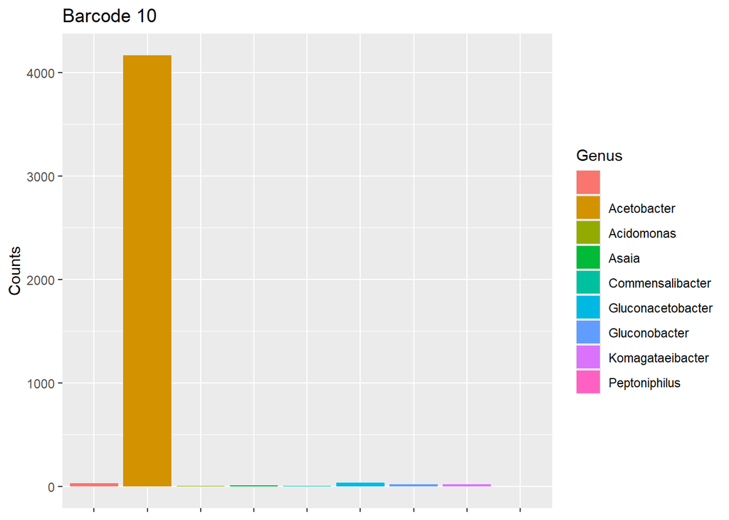

```r
#This is the code to make the plots

barcode_data %>%
  select(barcode, genus) %>%
  filter(barcode == "barcode10" & !is.na(genus)) %>% #Change the "barcode01" argument for the barcode you wish to plot
  ggplot() +
  geom_bar(aes(x = genus, fill = genus)) +
  labs(title = "Barcode 10", y = "Counts", fill = "Genus") +
  theme(axis.text.x = element_blank(), axis.title.x = element_blank())
```

```r
#ggsave("Bar_plot_genus_barcode10.png") #REMEMBER TO CHANGE THE NAME TO THE BARCODE YOU ARE PLOTTING
```

#### Counting the genus to compare with Epi2Me results

```r
barcode_data %>%
  select(barcode, genus) %>%
  filter(barcode == "barcode10" & !is.na(genus)) %>%
  count(genus)
```

```
##               genus    n
## 1                     30
## 2       Acetobacter 4169
## 3        Acidomonas    2
## 4             Asaia    8
## 5  Commensalibacter    2
## 6 Gluconacetobacter   36
## 7     Gluconobacter   18
## 8  Komagataeibacter   20
## 9     Peptoniphilus    1
```

### Barcode 11

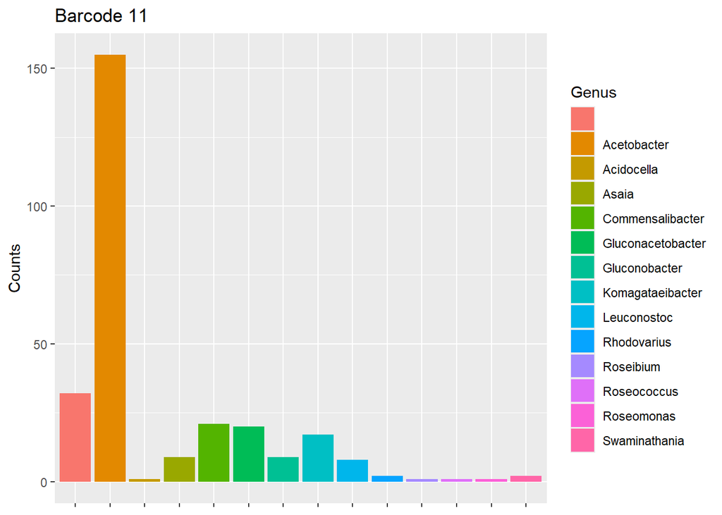

```r
#This is the code to make the plots

barcode_data %>%
  select(barcode, genus) %>%
  filter(barcode == "barcode11" & !is.na(genus)) %>% #Change the "barcode01" argument for the barcode you wish to plot
  ggplot() +
  geom_bar(aes(x = genus, fill = genus)) +
  labs(title = "Barcode 11", y = "Counts", fill = "Genus") +
  theme(axis.text.x = element_blank(), axis.title.x = element_blank())
```

```r
#ggsave("Bar_plot_genus_barcode11.png") #REMEMBER TO CHANGE THE NAME TO THE BARCODE YOU ARE PLOTTING
```

#### Counting the genus to compare with Epi2Me results

```r
barcode_data %>%
  select(barcode, genus) %>%
  filter(barcode == "barcode11" & !is.na(genus)) %>%
  count(genus)
```

```
##                genus   n
## 1                     32
## 2        Acetobacter 155
## 3         Acidocella   1
## 4              Asaia   9
## 5   Commensalibacter  21
## 6  Gluconacetobacter  20
## 7      Gluconobacter   9
## 8   Komagataeibacter  17
## 9        Leuconostoc   8
## 10       Rhodovarius   2
## 11         Roseibium   1
## 12       Roseococcus   1
## 13        Roseomonas   1
## 14     Swaminathania   2
```

### Barcode 12

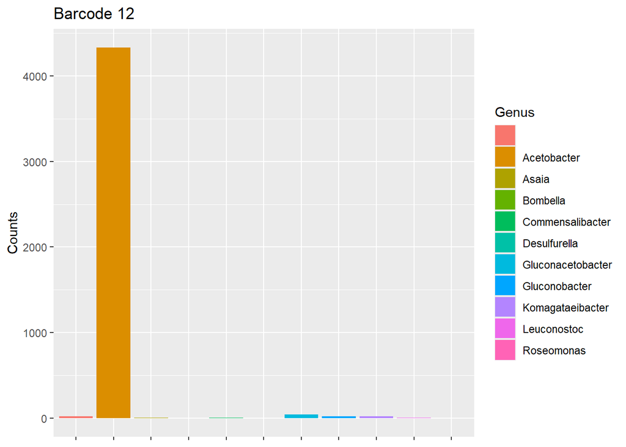

```r
#This is the code to make the plots

barcode_data %>%
  select(barcode, genus) %>%
  filter(barcode == "barcode12" & !is.na(genus)) %>% #Change the "barcode01" argument for the barcode you wish to plot
  ggplot() +
  geom_bar(aes(x = genus, fill = genus)) +
  labs(title = "Barcode 12", y = "Counts", fill = "Genus") +
  theme(axis.text.x = element_blank(), axis.title.x = element_blank())
```

```r
#ggsave("Bar_plot_genus_barcode12.png") #REMEMBER TO CHANGE THE NAME TO THE BARCODE YOU ARE PLOTTING
```

#### Counting the genus to compare with Epi2Me results

```r
barcode_data %>%
  select(barcode, genus) %>%
  filter(barcode == "barcode12" & !is.na(genus)) %>%
  count(genus)
```

```
##                genus    n
## 1                      23
## 2        Acetobacter 4335
## 3              Asaia    4
## 4           Bombella    1
## 5   Commensalibacter    2
## 6       Desulfurella    1
## 7  Gluconacetobacter   41
## 8      Gluconobacter   19
## 9   Komagataeibacter   23
## 10       Leuconostoc    4
## 11        Roseomonas    1
```

### Barcode 13

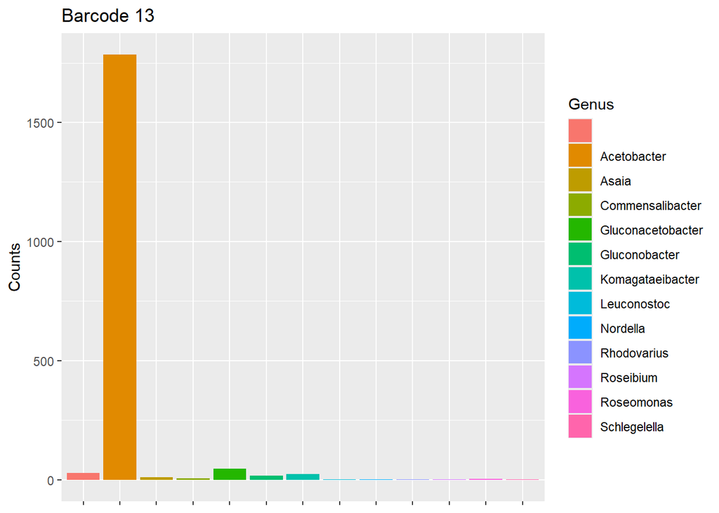

```r
#This is the code to make the plots

barcode_data %>%
  select(barcode, genus) %>%
  filter(barcode == "barcode13" & !is.na(genus)) %>% #Change the "barcode01" argument for the barcode you wish to plot
  ggplot() +
  geom_bar(aes(x = genus, fill = genus)) +
  labs(title = "Barcode 13", y = "Counts", fill = "Genus") +
  theme(axis.text.x = element_blank(), axis.title.x = element_blank())
```

```r
#ggsave("Bar_plot_genus_barcode13.png") #REMEMBER TO CHANGE THE NAME TO THE BARCODE YOU ARE PLOTTING
```

#### Counting the genus to compare with Epi2Me results

```r
barcode_data %>%
  select(barcode, genus) %>%
  filter(barcode == "barcode13" & !is.na(genus)) %>%
  count(genus)
```

```
##                genus    n
## 1                      28
## 2        Acetobacter 1786
## 3              Asaia   10
## 4   Commensalibacter    7
## 5  Gluconacetobacter   46
## 6      Gluconobacter   17
## 7   Komagataeibacter   25
## 8        Leuconostoc    1
## 9           Nordella    1
## 10       Rhodovarius    2
## 11         Roseibium    1
## 12        Roseomonas    3
## 13      Schlegelella    1
```

### Barcode 14

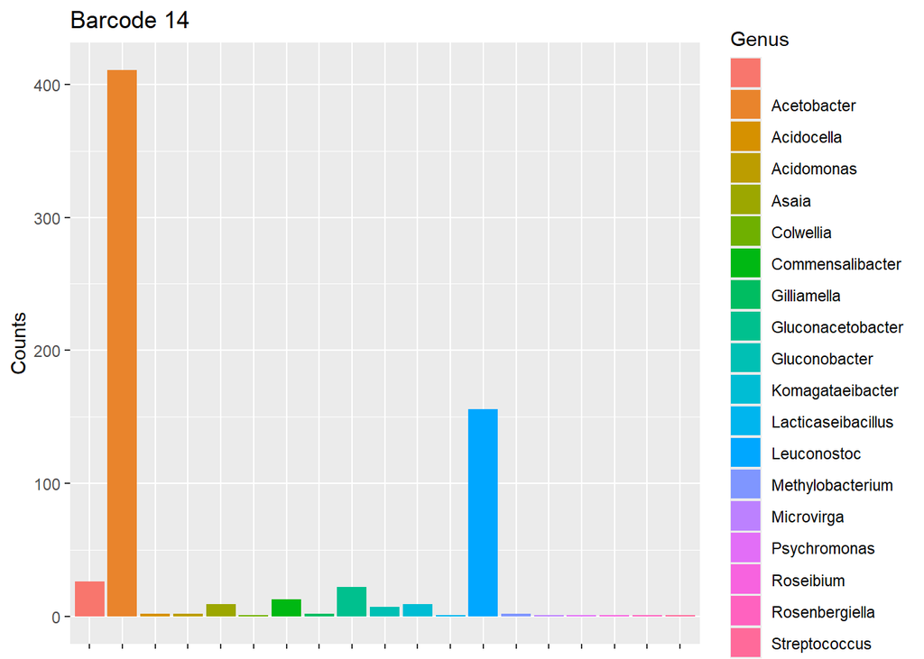

```r
#This is the code to make the plots

barcode_data %>%
  select(barcode, genus) %>%
  filter(barcode == "barcode14" & !is.na(genus)) %>% #Change the "barcode01" argument for the barcode you wish to plot
  ggplot() +
  geom_bar(aes(x = genus, fill = genus)) +
  labs(title = "Barcode 14", y = "Counts", fill = "Genus") +
  theme(axis.text.x = element_blank(), axis.title.x = element_blank())
```

```r
#ggsave("Bar_plot_genus_barcode14.png") #REMEMBER TO CHANGE THE NAME TO THE BARCODE YOU ARE PLOTTING
```

#### Counting the genus to compare with Epi2Me results

```r
barcode_data %>%
  select(barcode, genus) %>%
  filter(barcode == "barcode14" & !is.na(genus)) %>%
  count(genus)
```

```
##                 genus   n
## 1                      26
## 2         Acetobacter 411
## 3          Acidocella   2
## 4          Acidomonas   2
## 5               Asaia   9
## 6           Colwellia   1
## 7    Commensalibacter  13
## 8         Gilliamella   2
## 9   Gluconacetobacter  22
## 10      Gluconobacter   7
## 11   Komagataeibacter   9
## 12 Lacticaseibacillus   1
## 13        Leuconostoc 156
## 14   Methylobacterium   2
## 15         Microvirga   1
## 16       Psychromonas   1
## 17          Roseibium   1
## 18     Rosenbergiella   1
## 19      Streptococcus   1
```

### Barcode 15

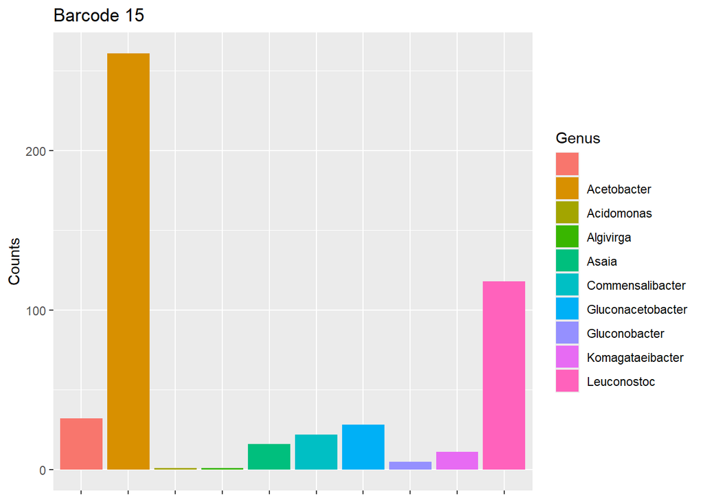

```r
#This is the code to make the plots

barcode_data %>%
  select(barcode, genus) %>%
  filter(barcode == "barcode15" & !is.na(genus)) %>% #Change the "barcode01" argument for the barcode you wish to plot
  ggplot() +
  geom_bar(aes(x = genus, fill = genus)) +
  labs(title = "Barcode 15", y = "Counts", fill = "Genus") +
  theme(axis.text.x = element_blank(), axis.title.x = element_blank())
```

```r
#ggsave("Bar_plot_genus_barcode15.png") #REMEMBER TO CHANGE THE NAME TO THE BARCODE YOU ARE PLOTTING
```

#### Counting the genus to compare with Epi2Me results

```r
barcode_data %>%
  select(barcode, genus) %>%
  filter(barcode == "barcode15" & !is.na(genus)) %>%
  count(genus)
```

```
##                genus   n
## 1                     32
## 2        Acetobacter 261
## 3         Acidomonas   1
## 4          Algivirga   1
## 5              Asaia  16
## 6   Commensalibacter  22
## 7  Gluconacetobacter  28
## 8      Gluconobacter   5
## 9   Komagataeibacter  11
## 10       Leuconostoc 118
```

### Barcode 16

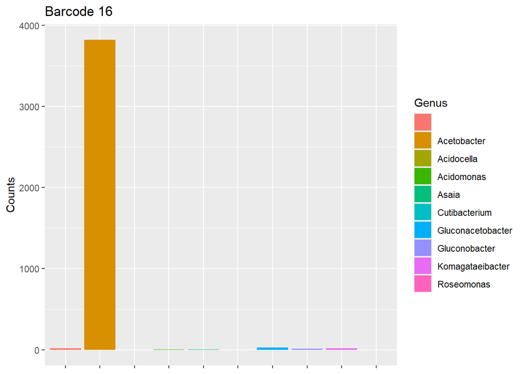

```r
#This is the code to make the plots

barcode_data %>%
  select(barcode, genus) %>%
  filter(barcode == "barcode16" & !is.na(genus)) %>% #Change the "barcode01" argument for the barcode you wish to plot
  ggplot() +
  geom_bar(aes(x = genus, fill = genus)) +
  labs(title = "Barcode 16", y = "Counts", fill = "Genus") +
  theme(axis.text.x = element_blank(), axis.title.x = element_blank())
```

```r
#ggsave("Bar_plot_genus_barcode16.png") #REMEMBER TO CHANGE THE NAME TO THE BARCODE YOU ARE PLOTTING
```

#### Counting the genus to compare with Epi2Me results

```r
barcode_data %>%
  select(barcode, genus) %>%
  filter(barcode == "barcode16" & !is.na(genus)) %>%
  count(genus)
```

```
##                genus    n
## 1                      18
## 2        Acetobacter 3823
## 3         Acidocella    1
## 4         Acidomonas    2
## 5              Asaia    2
## 6      Cutibacterium    1
## 7  Gluconacetobacter   28
## 8      Gluconobacter   12
## 9   Komagataeibacter   18
## 10        Roseomonas    1
```

### Barcode 17

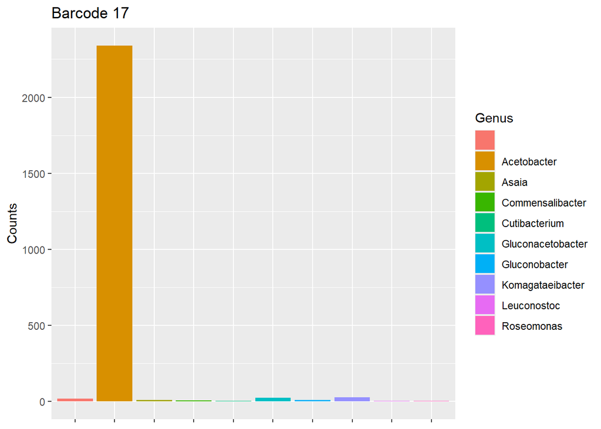

```r
#This is the code to make the plots

barcode_data %>%
  select(barcode, genus) %>%
  filter(barcode == "barcode17" & !is.na(genus)) %>% #Change the "barcode01" argument for the barcode you wish to plot
  ggplot() +
  geom_bar(aes(x = genus, fill = genus)) +
  labs(title = "Barcode 17", y = "Counts", fill = "Genus") +
  theme(axis.text.x = element_blank(), axis.title.x = element_blank())
```

```r
#ggsave("Bar_plot_genus_barcode17.png") #REMEMBER TO CHANGE THE NAME TO THE BARCODE YOU ARE PLOTTING
```

#### Counting the genus to compare with Epi2Me results

```r
barcode_data %>%
  select(barcode, genus) %>%
  filter(barcode == "barcode17" & !is.na(genus)) %>%
  count(genus)
```

```
##                genus    n
## 1                      17
## 2        Acetobacter 2341
## 3              Asaia    7
## 4   Commensalibacter    5
## 5      Cutibacterium    1
## 6  Gluconacetobacter   22
## 7      Gluconobacter    9
## 8   Komagataeibacter   25
## 9        Leuconostoc    1
## 10        Roseomonas    1
```

### Barcode 18

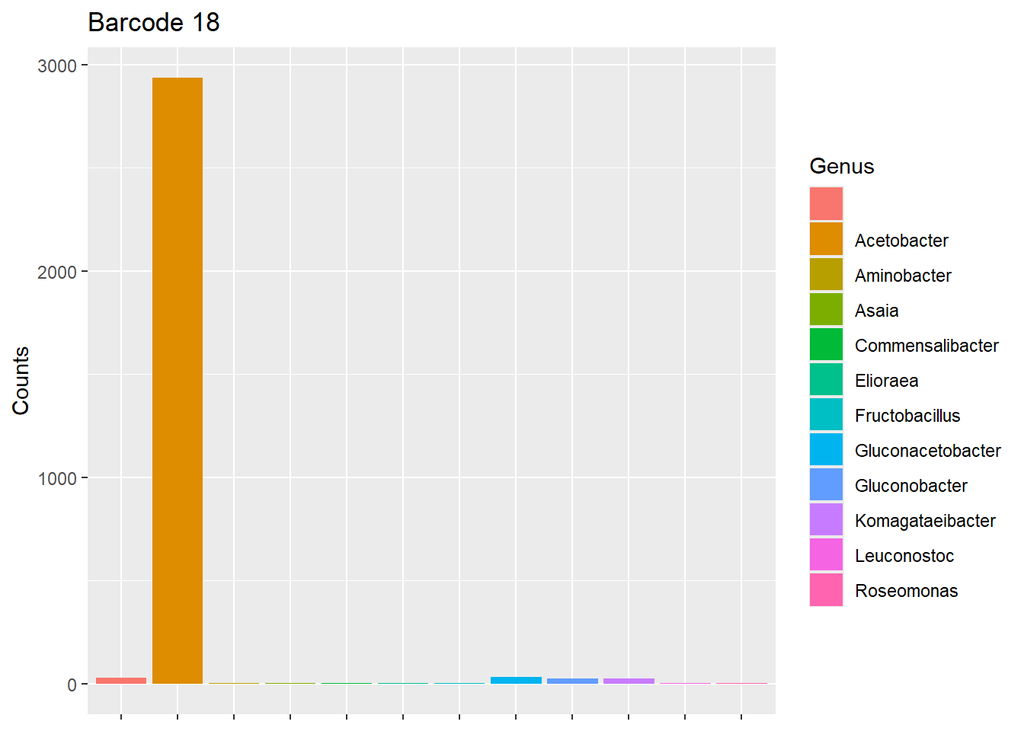

```r
#This is the code to make the plots

barcode_data %>%
  select(barcode, genus) %>%
  filter(barcode == "barcode18" & !is.na(genus)) %>% #Change the "barcode01" argument for the barcode you wish to plot
  ggplot() +
  geom_bar(aes(x = genus, fill = genus)) +
  labs(title = "Barcode 18", y = "Counts", fill = "Genus") +
  theme(axis.text.x = element_blank(), axis.title.x = element_blank())
```

```r
#ggsave("Bar_plot_genus_barcode18.png") #REMEMBER TO CHANGE THE NAME TO THE BARCODE YOU ARE PLOTTING
```

#### Counting the genus to compare with Epi2Me results

```r
barcode_data %>%
  select(barcode, genus) %>%
  filter(barcode == "barcode18" & !is.na(genus)) %>%
  count(genus)
```

```
##                genus    n
## 1                      28
## 2        Acetobacter 2939
## 3        Aminobacter    1
## 4              Asaia    4
## 5   Commensalibacter    1
## 6           Elioraea    1
## 7     Fructobacillus    1
## 8  Gluconacetobacter   32
## 9      Gluconobacter   25
## 10  Komagataeibacter   25
## 11       Leuconostoc    2
## 12        Roseomonas    1
```

**PARA UNIR LOS SAMPLES, HACER AVERAGE Y STANDARD ERROR. INCLUIR MAYBE EL GEOM_POINT() DE LOS CONTEOS**

##Preparing the colour palette

Since because of the high number of variables, a new color palette with discrete colors has to be created to avoid the colours in the barplots from blending together. We use the randomColoR package for this.

*As color selection is random, colors will change whenever the following chunk is run. Thus, plots will likely look different whenever we run the next chunk.*

For the sake of reproducibility, the randomcoloR package was only used to produce 100 distinctive colors to manually copy and paste into a list. This makes it so that the plots will always look the same whenever we run the script, on top of allowing to manually change the colors to be used in the plot.

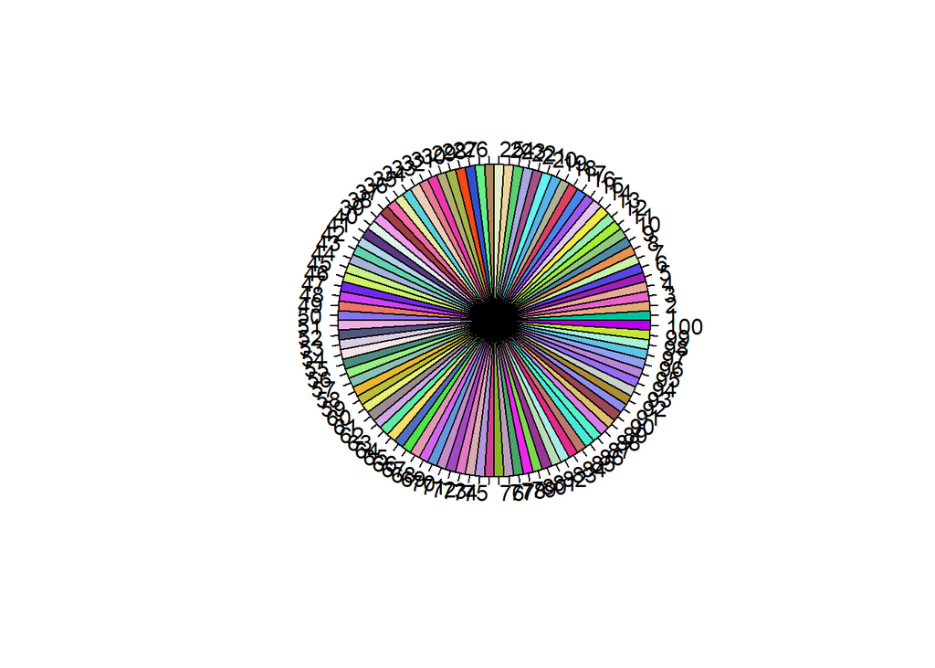

```r
colour_scale = c("#00C39D", "#E3AC77", "#E663CB", "#EAA794", "#A01FB7",
                 "#5845E1", "#C6F3AA", "#EA9051", "#5389A2","#92CA7F",
                 "#A0F133", "#95F0AC", "#F4EB46", "#E4C5F0", "#A158EC",
                 "#4B83F1", "#DB4163", "#B3B296","#55B3E8", "#62F4F3",
                 "#A45389", "#A8A6E3", "#59D073", "#F0D49C", "#E3EFC9",
                 "#AB8760", "#63F386","#3151CC", "#F6471B", "#A3B54E",
                 "#B0B073", "#EB39AB", "#E57A90", "#EACEB5", "#5CD1D9",
                 "#E5EBA0","#F16BA5", "#A63E45", "#EE9BE9", "#DEF2E8",
                 "#5D3887", "#B1D4E8", "#61D4AD", "#A5B2D9", "#C7F087",
                 "#CCF263", "#7228ED", "#CE43F4", "#EC756A", "#8676EA",
                 "#EFAEE2", "#51567F", "#D9CDE2", "#F5E4E7","#4C8D7E",
                 "#9AED83", "#89C1B6", "#EBB82D", "#BCBD39", "#E8F174",
                 "#9C8B92", "#CFA7EA", "#5AEDA4","#F7DE6C", "#506FC0",
                 "#4FE641", "#E198B2", "#D466EE", "#6399DB", "#C78CC7",
                 "#A449C2", "#E17AC0","#D8ADB3", "#B397DE", "#C94592",
                 "#86B724", "#BC9DC1", "#4BA469", "#ED27ED", "#80D74F",
                 "#963794", "#BADDB4", "#AAEBE9", "#E42A87", "#BD796B",
                 "#48EAD8", "#53F4C8", "#D47FE4", "#E0C16E", "#9B4757",
                 "#918DEF", "#AD8D33", "#C7D2CC", "#996EF3", "#B786DB",
                 "#91A0F2", "#5DC5E5", "#A7F4D5", "#C4E637", "#B700E8")

pie(rep(1, 100), col=colour_scale)
```

##Classifying the barcodes in their respective sample groups

[figure not shown]

```r
barcode_data %>%
  select(barcode, genus) %>%
  mutate(sample_group = case_when(
    barcode == "barcode01" | barcode == "barcode02" | barcode == "barcode03" ~ "young_5d_0expo",
    barcode == "barcode04" | barcode == "barcode05" | barcode == "barcode06" ~ "young_5d_1expo",
    barcode == "barcode08" | barcode == "barcode09" ~ "young_5d_2expo",
    barcode == "barcode10" | barcode == "barcode11" | barcode == "barcode12" ~ "old_50d_0expo",
    barcode == "barcode13" | barcode == "barcode14" | barcode == "barcode15" ~ "old_50d_1expo",
    barcode == "barcode16" | barcode == "barcode17" | barcode == "barcode18" ~ "old_50d_2expo",
    TRUE ~ NA)) %>%
  filter(!is.na(genus), !is.na(sample_group)) %>%  #Change the "barcode01" argument for the barcode you wish to plot
  ggplot() +
  geom_bar(aes(x = sample_group, fill = genus), position = "fill") +
  scale_y_continuous(labels = scales::percent) +
  scale_fill_manual(values = colour_scale) +
  labs(title = "Genus per Sample", y = "", fill = "Genus") +
  theme(axis.title.x = element_blank(),
        axis.text.x = element_text(angle = -45, hjust = 0.01))
```

```r
ggsave("Genus_per_sample_Jan.png", height = 7, width = 10, limitsize = FALSE)
```

## Genus per barcodes (separated in old and young flies)

###Young Flies

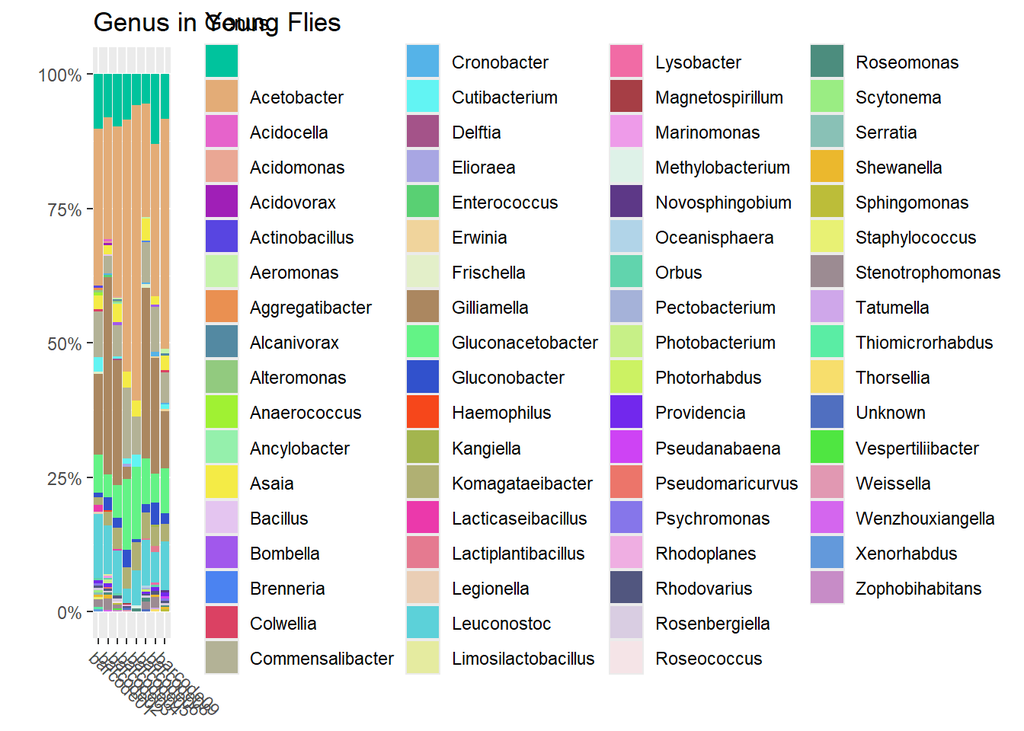

```r
barcode_data %>%
  select(barcode, genus) %>%
  mutate(sample_group = case_when(
    barcode == "barcode01" | barcode == "barcode02" | barcode == "barcode03" ~ "young_5d_0expo",
    barcode == "barcode04" | barcode == "barcode05" | barcode == "barcode06" ~ "young_5d_1expo",
    barcode == "barcode08" | barcode == "barcode09" ~ "young_5d_2expo",
    barcode == "barcode10" | barcode == "barcode11" | barcode == "barcode12" ~ "old_50d_0expo",
    barcode == "barcode13" | barcode == "barcode14" | barcode == "barcode15" ~ "old_50d_1expo",
    barcode == "barcode16" | barcode == "barcode17" | barcode == "barcode18" ~ "old_50d_2expo",
    TRUE ~ NA)) %>%
  filter(!is.na(genus), !is.na(sample_group),
         sample_group == "young_5d_0expo" |
          sample_group == "young_5d_1expo" |
           sample_group == "young_5d_2expo") %>%  #Change the "barcode01" argument for the barcode you wish to plot
  ggplot() +
  geom_bar(aes(x = barcode, fill = genus), position = "fill") +
  scale_y_continuous(labels = scales::percent) +
  scale_fill_manual(values = colour_scale) +
  labs(title = "Genus in Young Flies", y = "", fill = "Genus") +
  theme(axis.title.x = element_blank(),
        axis.text.x = element_text(angle = -45, hjust = 0.01))
```

```r
ggsave("Genus_young_flies_Jan.png", height = 7, width = 10, limitsize = FALSE)
```

###Old Flies

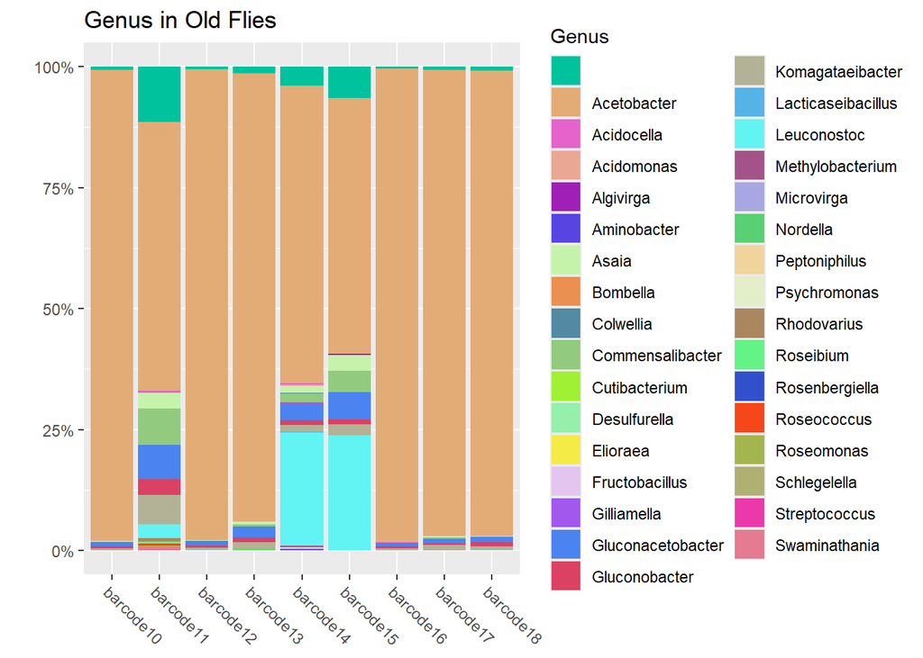

```r
barcode_data %>%
  select(barcode, genus) %>%
  mutate(sample_group = case_when(
    barcode == "barcode01" | barcode == "barcode02" | barcode == "barcode03" ~ "young_5d_0expo",
    barcode == "barcode04" | barcode == "barcode05" | barcode == "barcode06" ~ "young_5d_1expo",
    barcode == "barcode08" | barcode == "barcode09" ~ "young_5d_2expo",
    barcode == "barcode10" | barcode == "barcode11" | barcode == "barcode12" ~ "old_50d_0expo",
    barcode == "barcode13" | barcode == "barcode14" | barcode == "barcode15" ~ "old_50d_1expo",
    barcode == "barcode16" | barcode == "barcode17" | barcode == "barcode18" ~ "old_50d_2expo",
    TRUE ~ NA)) %>%
  filter(!is.na(genus), !is.na(sample_group),
         sample_group == "old_50d_0expo" |
          sample_group == "old_50d_1expo" |
           sample_group == "old_50d_2expo") %>%  #Change the "barcode01" argument for the barcode you wish to plot
  ggplot() +
  geom_bar(aes(x = barcode, fill = genus), position = "fill") +
  scale_y_continuous(labels = scales::percent) +
  scale_fill_manual(values = colour_scale) +
  labs(title = "Genus in Old Flies", y = "", fill = "Genus") +
  theme(axis.title.x = element_blank(),
        axis.text.x = element_text(angle = -45, hjust = 0.01))
```

```r
ggsave("Genus_old_flies_Jan.png", height = 7, width = 10, limitsize = FALSE)
```

[figure not shown]

```r
barcode_data %>%
  select(barcode, genus, species) %>%
  mutate(sample_group = case_when(
    barcode == "barcode01" | barcode == "barcode02" | barcode == "barcode03" ~ "young_5d_0expo",
    barcode == "barcode04" | barcode == "barcode05" | barcode == "barcode06" ~ "young_5d_1expo",
    barcode == "barcode08" | barcode == "barcode09" ~ "young_5d_2expo",
    barcode == "barcode10" | barcode == "barcode11" | barcode == "barcode12" ~ "old_50d_0expo",
    barcode == "barcode13" | barcode == "barcode14" | barcode == "barcode15" ~ "old_50d_1expo",
    barcode == "barcode16" | barcode == "barcode17" | barcode == "barcode18" ~ "old_50d_2expo",
    TRUE ~ NA)) %>%
  filter(genus == "Acetobacter", !is.na(sample_group)) %>%  #Change the "barcode01" argument for the barcode you wish to plot
  ggplot() +
  geom_bar(aes(x = sample_group, fill = species), position = "fill") +
  scale_y_continuous(labels = scales::percent) +
  scale_fill_manual(values = colour_scale) +
  labs(title = "Acetobacter Species per Sample", y = "", fill = "species") +
  theme(axis.title.x = element_blank(),
        axis.text.x = element_text(angle = -45, hjust = 0.01))
```

```r
ggsave("Aceobacter_species_per_sample_Jan.png", height = 7, width = 15, limitsize = FALSE)
```

##Acetobacter Species per barcode (separated in young and old flies)

### Young Flies

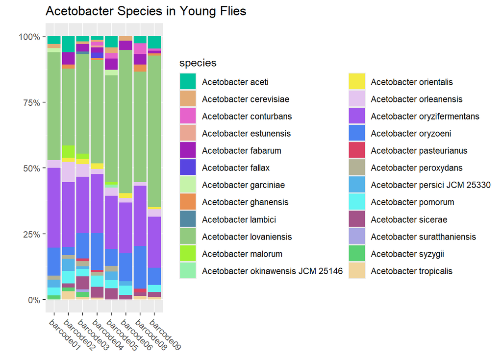

```r
barcode_data %>%
  select(barcode, genus, species) %>%
  mutate(sample_group = case_when(
    barcode == "barcode01" | barcode == "barcode02" | barcode == "barcode03" ~ "young_5d_0expo",
    barcode == "barcode04" | barcode == "barcode05" | barcode == "barcode06" ~ "young_5d_1expo",
    barcode == "barcode08" | barcode == "barcode09" ~ "young_5d_2expo",
    barcode == "barcode10" | barcode == "barcode11" | barcode == "barcode12" ~ "old_50d_0expo",
    barcode == "barcode13" | barcode == "barcode14" | barcode == "barcode15" ~ "old_50d_1expo",
    barcode == "barcode16" | barcode == "barcode17" | barcode == "barcode18" ~ "old_50d_2expo",
    TRUE ~ NA)) %>%
  filter(genus == "Acetobacter", !is.na(sample_group),
         sample_group == "young_5d_0expo" |
          sample_group == "young_5d_1expo" |
           sample_group == "young_5d_2expo") %>%  #Change the "barcode01" argument for the barcode you wish to plot
  ggplot() +
  geom_bar(aes(x = barcode, fill = species), position = "fill") +
  scale_y_continuous(labels = scales::percent) +
  scale_fill_manual(values = colour_scale) +
  labs(title = "Acetobacter Species in Young Flies", y = "", fill = "species") +
  theme(axis.title.x = element_blank(),
        axis.text.x = element_text(angle = -45, hjust = 0.01))
```

```r
ggsave("Aceobacter_species_young_flies_Jan.png", height = 7, width = 15, limitsize = FALSE)
```

### Old Flies

[figure not shown]

```r
barcode_data %>%
  select(barcode, genus, species) %>%
  mutate(sample_group = case_when(
    barcode == "barcode01" | barcode == "barcode02" | barcode == "barcode03" ~ "young_5d_0expo",
    barcode == "barcode04" | barcode == "barcode05" | barcode == "barcode06" ~ "young_5d_1expo",
    barcode == "barcode08" | barcode == "barcode09" ~ "young_5d_2expo",
    barcode == "barcode10" | barcode == "barcode11" | barcode == "barcode12" ~ "old_50d_0expo",
    barcode == "barcode13" | barcode == "barcode14" | barcode == "barcode15" ~ "old_50d_1expo",
    barcode == "barcode16" | barcode == "barcode17" | barcode == "barcode18" ~ "old_50d_2expo",
    TRUE ~ NA)) %>%
  filter(genus == "Acetobacter", !is.na(sample_group),
         sample_group == "old_50d_0expo" |
          sample_group == "old_50d_1expo" |
           sample_group == "old_50d_2expo") %>%  #Change the "barcode01" argument for the barcode you wish to plot
  ggplot() +
  geom_bar(aes(x = barcode, fill = species), position = "fill") +
  scale_y_continuous(labels = scales::percent) +
  scale_fill_manual(values = colour_scale) +
  labs(title = "Acetobacter Species in Old Flies", y = "", fill = "species") +
  theme(axis.title.x = element_blank(),
        axis.text.x = element_text(angle = -45, hjust = 0.01))
```

```r
ggsave("Aceobacter_species_old_flies_Jan.png", height = 7, width = 15, limitsize = FALSE)
```

[figure not shown]

```r
barcode_data %>%
  select(barcode, genus, species) %>%
  mutate(sample_group = case_when(
    barcode == "barcode01" | barcode == "barcode02" | barcode == "barcode03" ~ "young_5d_0expo",
    barcode == "barcode04" | barcode == "barcode05" | barcode == "barcode06" ~ "young_5d_1expo",
    barcode == "barcode08" | barcode == "barcode09" ~ "young_5d_2expo",
    barcode == "barcode10" | barcode == "barcode11" | barcode == "barcode12" ~ "old_50d_0expo",
    barcode == "barcode13" | barcode == "barcode14" | barcode == "barcode15" ~ "old_50d_1expo",
    barcode == "barcode16" | barcode == "barcode17" | barcode == "barcode18" ~ "old_50d_2expo",
    TRUE ~ NA)) %>%
  filter(genus == "Acetobacter", !is.na(sample_group)) %>%  #Change the "barcode01" argument for the barcode you wish to plot
  ggplot() +
  geom_bar(aes(x = sample_group, fill = species), position = "fill") +
  scale_y_continuous(labels = scales::percent) +
  scale_fill_manual(values = colour_scale) +
  labs(title = "Acetobacter Species per Sample", y = "", fill = "species") +
  theme(axis.title.x = element_blank(),
        axis.text.x = element_text(angle = -45, hjust = 0.01))
```